# Data analysis and visualisation in Python

#### [@SekouLRemy](https://twitter.com/SekouLRemy)

Content in sync with work developed by Harrison J Goldwyn and Dina Mistry

###### Apache License 2.0 (Apache-2.0)

## Learning Objectives

By the end of this lecture, participants should understand:

- What are basic data types and operations which can be performed on data
- How to load data within a Pandas DataFrame
- How to perform common data modifications
- How Pandas as a framework helps in data analysis
- How to visualise data with widely used modules

```python
1 + 2
```

```python
[1, 2, 3] + [4]
```

[5, 6, 7] ??

[1, 2, 3, 4] ??

## It all comes down to the defintion of '+'

## '+' is actually a function!

## '+' has parameters

(1, 2)

([1, 2, 3], [4])

## 1 + 2 ==> integer_addition (1, 2)

```python
1+2
```

```
3
```

```python
[1, 2, 3] + [4]
```

```
[1, 2, 3, 4]
```

```python
[1, 2, 3] + 4
```

```
---------------------------------------------------------------------------
TypeError                                 Traceback (most recent call last)
<ipython-input-6-5842ff442cc5> in <module>
----> 1 [1, 2, 3] + 4

TypeError: can only concatenate list (not "int") to list
```

```python
# common datatypes

int, float, list, str, tuple
```

```python
import pandas as pd
```

```python
pd.DataFrame([1, 2, 3]).median()
```

```
0    2.0
dtype: float64
```

Pause!

Loading and Manipulating Data..

```python
# Assumes mydata.csv exists!
data = pd.read_csv("mydata.csv")
```

```python
# WHO Coronavirus (COVID-19) Dashboard
data = pd.read_csv("https://covid19.who.int/WHO-COVID-19-global-data.csv", parse_dates=["Date_reported"])
```

```python
data.columns
```

```
Index(['Date_reported', 'Country_code', 'Country', 'WHO_region', 'New_cases',
       'Cumulative_cases', 'New_deaths', 'Cumulative_deaths'],
      dtype='object')
```

```python
data.dtypes
```

```
Date_reported        datetime64[ns]
Country_code                 object
Country                      object
WHO_region                   object
New_cases                     int64
Cumulative_cases              int64
New_deaths                    int64
Cumulative_deaths             int64
dtype: object
```

```python
data.Country_code
```

```
0         AF
1         AF
2         AF
3         AF
4         AF
          ..
188410    ZW
188411    ZW
188412    ZW
188413    ZW
188414    ZW
Name: Country_code, Length: 188415, dtype: object
```

```python
data["Country_code"]
```

```
0         AF
1         AF
2         AF
3         AF
4         AF
          ..
188410    ZW
188411    ZW
188412    ZW
188413    ZW
188414    ZW
Name: Country_code, Length: 188415, dtype: object
```

```python
data.Country_code=="KE"
```

```
0         False
1         False
2         False
3         False
4         False
          ...
188410    False
188411    False
188412    False
188413    False
188414    False
Name: Country_code, Length: 188415, dtype: bool
```

```python
data[data.Country_code=="KE"].head()
```

|  | Date_reported | Country_code | Country | WHO_region | New_cases | Cumulative_cases | New_deaths | Cumulative_deaths |
| --- | --- | --- | --- | --- | --- | --- | --- | --- |
| 86655 | 2020-01-03 | KE | Kenya | AFRO | 0 | 0 | 0 | 0 |
| 86656 | 2020-01-04 | KE | Kenya | AFRO | 0 | 0 | 0 | 0 |
| 86657 | 2020-01-05 | KE | Kenya | AFRO | 0 | 0 | 0 | 0 |
| 86658 | 2020-01-06 | KE | Kenya | AFRO | 0 | 0 | 0 | 0 |
| 86659 | 2020-01-07 | KE | Kenya | AFRO | 0 | 0 | 0 | 0 |

```python
data[data.Country_code=="KE"].tail()
```

|  | Date_reported | Country_code | Country | WHO_region | New_cases | Cumulative_cases | New_deaths | Cumulative_deaths |
| --- | --- | --- | --- | --- | --- | --- | --- | --- |
| 87445 | 2022-03-03 | KE | Kenya | AFRO | 24 | 323002 | 1 | 5640 |
| 87446 | 2022-03-04 | KE | Kenya | AFRO | 23 | 323025 | 0 | 5640 |
| 87447 | 2022-03-05 | KE | Kenya | AFRO | 32 | 323057 | 0 | 5640 |
| 87448 | 2022-03-06 | KE | Kenya | AFRO | 14 | 323071 | 0 | 5640 |
| 87449 | 2022-03-07 | KE | Kenya | AFRO | 4 | 323075 | 1 | 5641 |

```python
# data.dropna(inplace=true)??

data_new = data[data.Country_code=="KE"].drop_duplicates().sort_values('Date_reported').set_index('Date_reported')
```

```python
data_new.head()
```

| Date_reported | Country_code | Country | WHO_region | New_cases | Cumulative_cases | New_deaths | Cumulative_deaths |
| --- | --- | --- | --- | --- | --- | --- | --- |
| 2020-01-03 | KE | Kenya | AFRO | 0 | 0 | 0 | 0 |
| 2020-01-04 | KE | Kenya | AFRO | 0 | 0 | 0 | 0 |
| 2020-01-05 | KE | Kenya | AFRO | 0 | 0 | 0 | 0 |
| 2020-01-06 | KE | Kenya | AFRO | 0 | 0 | 0 | 0 |
| 2020-01-07 | KE | Kenya | AFRO | 0 | 0 | 0 | 0 |

```python
# Basic summary statistics
data_new.describe()
```

|  | New_cases | Cumulative_cases | New_deaths | Cumulative_deaths |
| --- | --- | --- | --- | --- |
| count | 795.000000 | 795.000000 | 795.000000 | 795.000000 |
| mean | 406.383648 | 123167.900629 | 7.095597 | 2314.914465 |
| std | 550.464471 | 107294.520882 | 8.296363 | 2061.279848 |
| min | 0.000000 | 0.000000 | 0.000000 | 0.000000 |
| 25% | 46.500000 | 13051.500000 | 0.000000 | 229.500000 |
| 50% | 190.000000 | 101009.000000 | 4.000000 | 1766.000000 |
| 75% | 576.500000 | 226370.000000 | 11.000000 | 4419.500000 |
| max | 4918.000000 | 323075.000000 | 39.000000 | 5641.000000 |

```python
data[data.Country_code=="UG"].describe()
```

|  | New_cases | Cumulative_cases | New_deaths | Cumulative_deaths |
| --- | --- | --- | --- | --- |
| count | 795.000000 | 795.000000 | 795.000000 | 795.000000 |
| mean | 205.513208 | 52734.261635 | 4.513208 | 1088.127044 |
| std | 811.633354 | 55183.724174 | 29.538145 | 1403.161079 |
| min | 0.000000 | 0.000000 | -36.000000 | 0.000000 |
| 25% | 9.000000 | 1061.500000 | 0.000000 | 0.000000 |
| 50% | 52.000000 | 39651.000000 | 0.000000 | 325.000000 |
| 75% | 182.500000 | 118323.500000 | 3.000000 | 2942.500000 |
| max | 20692.000000 | 163383.000000 | 799.000000 | 3588.000000 |

Exploring Case Numbers..

```python
data_new.Cumulative_cases
```

```
Date_reported
2020-01-03         0
2020-01-04         0
2020-01-05         0
2020-01-06         0
2020-01-07         0
               ...
2022-03-03    323002
2022-03-04    323025
2022-03-05    323057
2022-03-06    323071
2022-03-07    323075
Name: Cumulative_cases, Length: 795, dtype: int64
```

```python
data_new.New_cases.mean()
```

```
406.3836477987421
```

```python
data_new.New_cases.resample("M").sum()
```

```
Date_reported
2020-01-31        0
2020-02-29        0
2020-03-31       50
2020-04-30      334
2020-05-31     1504
2020-06-30     4302
2020-07-31    13723
2020-08-31    14144
2020-09-30     4321
2020-10-31    15419
2020-11-30    29519
2020-12-31    12935
2021-01-31     4424
2021-02-28     4973
2021-03-31    26998
2021-04-30    26175
2021-05-31    11826
2021-06-30    12956
2021-07-31    18351
2021-08-31    33344
2021-09-30    13876
2021-10-31     4119
2021-11-30     1686
2021-12-31    37258
2022-01-31    29098
2022-02-28     1595
2022-03-31      145
Freq: M, Name: New_cases, dtype: int64
```

```python
#A test!
#data_new.New_cases.resample("W").sum()

#what happens here?
data_new[data_new.index>'2021-08-08'].New_cases.resample("W").sum()
```

```
Date_reported
2021-08-15     8910
2021-08-22     8425
2021-08-29     6226
2021-09-05     5103
2021-09-12     3764
2021-09-19     2840
2021-09-26     2096
2021-10-03     1631
2021-10-10     1034
2021-10-17      902
2021-10-24      669
2021-10-31      665
2021-11-07      520
2021-11-14      463
2021-11-21      412
2021-11-28      252
2021-12-05      468
2021-12-12      726
2021-12-19     6201
2021-12-26    19023
2022-01-02    15797
2022-01-09    11975
2022-01-16     8194
2022-01-23     2814
2022-01-30     1096
2022-02-06      809
2022-02-13      393
2022-02-20      233
2022-02-27      237
2022-03-06      165
2022-03-13        4
Freq: W-SUN, Name: New_cases, dtype: int64
```

Merging Data from Different Sources..

```python
import requests
import zipfile
import os
from io import BytesIO

# Meta, "Movement Range Maps" Humanitarian Data Exchange. (Part1 and Part2 of the Data)
zf2020 = zipfile.ZipFile(BytesIO(requests.get("https://data.humdata.org/dataset/c3429f0e-651b-4788-bb2f-4adbf222c90e/resource/3d77ce5c-ab6d-4864-b8a2-c8bafffac4f3/download/movement-range-data-2020-03-01-2020-12-31.zip").content)) if not os.path.exists("movement-range-data-2020-03-01-2020-12-31.zip") else zipfile.ZipFile("movement-range-data-2020-03-01-2020-12-31.zip")
mobilitydata1 = pd.read_csv(zf2020.open('movement-range-data-2020-03-01--2020-12-31.txt'), delimiter="\t", parse_dates=["ds"], low_memory=False)

zf2021 = zipfile.ZipFile(BytesIO(requests.get("https://data.humdata.org/dataset/c3429f0e-651b-4788-bb2f-4adbf222c90e/resource/55a51014-0d27-49ae-bf92-c82a570c2c6c/download/movement-range-data-2022-03-06.zip").content)) if not os.path.exists("movement-range-data-2022-03-06.zip") else zipfile.ZipFile("movement-range-data-2022-03-06.zip")
mobilitydata2 = pd.read_csv(zf2021.open('movement-range-2022-03-06.txt'), delimiter="\t", parse_dates=["ds"], low_memory=False)
```

```python
mobilitydata = pd.concat(
    [mobilitydata1,
     mobilitydata2
    ],
    axis=0)
```

```python
mobilitydata.columns
```

```
Index(['ds', 'country', 'polygon_source', 'polygon_id', 'polygon_name',
       'all_day_bing_tiles_visited_relative_change',
       'all_day_ratio_single_tile_users', 'baseline_name', 'baseline_type'],
      dtype='object')
```

```python
mobilitydata[
    (mobilitydata.country == "KEN") ]
```

|  | ds | country | polygon_source | polygon_id | polygon_name | all_day_bing_tiles_visited_relative_change | all_day_ratio_single_tile_users | baseline_name | baseline_type |
| --- | --- | --- | --- | --- | --- | --- | --- | --- | --- |
| 2570785 | 2020-03-01 | KEN | GADM | KEN.10.1_1 | Kajiado Central | -0.14277 | 0.16011 | full_february | DAY_OF_WEEK |
| 2570786 | 2020-03-02 | KEN | GADM | KEN.10.1_1 | Kajiado Central | -0.18758 | 0.09824 | full_february | DAY_OF_WEEK |
| 2570787 | 2020-03-03 | KEN | GADM | KEN.10.1_1 | Kajiado Central | -0.07280 | 0.12918 | full_february | DAY_OF_WEEK |
| 2570788 | 2020-03-04 | KEN | GADM | KEN.10.1_1 | Kajiado Central | -0.02168 | 0.10025 | full_february | DAY_OF_WEEK |
| 2570789 | 2020-03-05 | KEN | GADM | KEN.10.1_1 | Kajiado Central | -0.01348 | 0.11649 | full_february | DAY_OF_WEEK |
| ... | ... | ... | ... | ... | ... | ... | ... | ... | ... |
| 2947837 | 2021-02-26 | KEN | GADM | KEN.9.1_1 | Isiolo North | -0.05177 | 0.14727 | full_february | DAY_OF_WEEK |
| 2947838 | 2021-05-20 | KEN | GADM | KEN.9.1_1 | Isiolo North | -0.01940 | 0.15364 | full_february | DAY_OF_WEEK |
| 2947839 | 2021-11-17 | KEN | GADM | KEN.9.1_1 | Isiolo North | -0.32613 | 0.27488 | full_february | DAY_OF_WEEK |
| 2947840 | 2021-11-23 | KEN | GADM | KEN.9.1_1 | Isiolo North | 0.04162 | 0.16696 | full_february | DAY_OF_WEEK |
| 2947841 | 2021-12-01 | KEN | GADM | KEN.9.1_1 | Isiolo North | -0.25720 | 0.26308 | full_february | DAY_OF_WEEK |

48069 rows × 9 columns

```python
mobilitydata[(mobilitydata.country == "KEN") & (mobilitydata.polygon_name == "Langata")].polygon_name.unique()
```

```
array(['Langata'], dtype=object)
```

```python
#Choices!

mobilitydata[(mobilitydata.country == "KEN")].groupby("ds").median()
mobilitydata[ (mobilitydata.country == "KEN") & (mobilitydata.polygon_name == 'Langata') ]
```

```python
mobilitydata_new = mobilitydata[
    (mobilitydata.country == "KEN") &
    (mobilitydata.polygon_name == 'Langata')
].drop_duplicates().sort_values('ds').set_index('ds')
```

```python
# (Global) Community Mobility Reports, Google

gmobility = pd.read_csv("https://www.gstatic.com/covid19/mobility/Global_Mobility_Report.csv", parse_dates=["date"], low_memory=False) if not os.path.exists("Global_Mobility_Report.csv") else pd.read_csv("Global_Mobility_Report.csv", parse_dates=["date"], low_memory=False)
```

```python
gmobility.columns
```

```
Index(['country_region_code', 'country_region', 'sub_region_1', 'sub_region_2',
       'metro_area', 'iso_3166_2_code', 'census_fips_code', 'place_id', 'date',
       'retail_and_recreation_percent_change_from_baseline',
       'grocery_and_pharmacy_percent_change_from_baseline',
       'parks_percent_change_from_baseline',
       'transit_stations_percent_change_from_baseline',
       'workplaces_percent_change_from_baseline',
       'residential_percent_change_from_baseline'],
      dtype='object')
```

```python
# Notice any potential issues with this filter?
gmobilitydata_new = gmobility[
    (gmobility.metro_area=='Nairobi Metropolitan Area')
].drop_duplicates().sort_values('date').set_index('date')
```

```python
gmobilitydata_new
```

| date | country_region_code | country_region | sub_region_1 | sub_region_2 | metro_area | iso_3166_2_code | census_fips_code | place_id | retail_and_recreation_percent_change_from_baseline | grocery_and_pharmacy_percent_change_from_baseline | parks_percent_change_from_baseline | transit_stations_percent_change_from_baseline | workplaces_percent_change_from_baseline | residential_percent_change_from_baseline |
| --- | --- | --- | --- | --- | --- | --- | --- | --- | --- | --- | --- | --- | --- | --- |
| 2020-02-15 | KE | Kenya | NaN | NaN | Nairobi Metropolitan Area | NaN | NaN | ChIJ011D4GkXLxgRVd4OS27StFk | 2.0 | 3.0 | 15.0 | 5.0 | 2.0 | -2.0 |
| 2020-02-16 | KE | Kenya | NaN | NaN | Nairobi Metropolitan Area | NaN | NaN | ChIJ011D4GkXLxgRVd4OS27StFk | 1.0 | -3.0 | 5.0 | 4.0 | 3.0 | 0.0 |
| 2020-02-17 | KE | Kenya | NaN | NaN | Nairobi Metropolitan Area | NaN | NaN | ChIJ011D4GkXLxgRVd4OS27StFk | 4.0 | -1.0 | 6.0 | 5.0 | 3.0 | 0.0 |
| 2020-02-18 | KE | Kenya | NaN | NaN | Nairobi Metropolitan Area | NaN | NaN | ChIJ011D4GkXLxgRVd4OS27StFk | 3.0 | -1.0 | 7.0 | 4.0 | 3.0 | 0.0 |
| 2020-02-19 | KE | Kenya | NaN | NaN | Nairobi Metropolitan Area | NaN | NaN | ChIJ011D4GkXLxgRVd4OS27StFk | 0.0 | -4.0 | 3.0 | 1.0 | 1.0 | 1.0 |
| ... | ... | ... | ... | ... | ... | ... | ... | ... | ... | ... | ... | ... | ... | ... |
| 2022-02-28 | KE | Kenya | NaN | NaN | Nairobi Metropolitan Area | NaN | NaN | ChIJ011D4GkXLxgRVd4OS27StFk | 42.0 | 49.0 | -2.0 | 68.0 | 28.0 | 8.0 |
| 2022-03-01 | KE | Kenya | NaN | NaN | Nairobi Metropolitan Area | NaN | NaN | ChIJ011D4GkXLxgRVd4OS27StFk | 42.0 | 52.0 | 3.0 | 72.0 | 27.0 | 8.0 |
| 2022-03-02 | KE | Kenya | NaN | NaN | Nairobi Metropolitan Area | NaN | NaN | ChIJ011D4GkXLxgRVd4OS27StFk | 44.0 | 52.0 | 3.0 | 73.0 | 27.0 | 9.0 |
| 2022-03-03 | KE | Kenya | NaN | NaN | Nairobi Metropolitan Area | NaN | NaN | ChIJ011D4GkXLxgRVd4OS27StFk | 47.0 | 54.0 | 15.0 | 76.0 | 26.0 | 8.0 |
| 2022-03-04 | KE | Kenya | NaN | NaN | Nairobi Metropolitan Area | NaN | NaN | ChIJ011D4GkXLxgRVd4OS27StFk | 49.0 | 59.0 | 16.0 | 79.0 | 30.0 | 9.0 |

749 rows × 14 columns

```python
 gmobilitydata_new.transit_stations_percent_change_from_baseline.resample("M").mean()
```

```
date
2020-02-29     3.800000
2020-03-31    -8.935484
2020-04-30   -42.166667
2020-05-31   -35.645161
2020-06-30   -26.466667
2020-07-31   -19.032258
2020-08-31   -12.548387
2020-09-30    -3.566667
2020-10-31    10.451613
2020-11-30    16.366667
2020-12-31    17.096774
2021-01-31    13.322581
2021-02-28    20.142857
2021-03-31    27.032258
2021-04-30    17.733333
2021-05-31    40.516129
2021-06-30    50.933333
2021-07-31    55.225806
2021-08-31    55.225806
2021-09-30    54.066667
2021-10-31    56.612903
2021-11-30    63.633333
2021-12-31    57.741935
2022-01-31    57.709677
2022-02-28    69.214286
2022-03-31    75.000000
Freq: M, Name: transit_stations_percent_change_from_baseline, dtype: float64
```

```python
#join all the data together in a single dataframe!
data_final = pd.concat(
    [data_new,
     mobilitydata_new,
     gmobilitydata_new
    ],
    axis=1,
    join="inner")
```

```python
data_final
```

|  | Country_code | Country | WHO_region | New_cases | Cumulative_cases | New_deaths | Cumulative_deaths | country | polygon_source | polygon_id | ... | metro_area | iso_3166_2_code | census_fips_code | place_id | retail_and_recreation_percent_change_from_baseline | grocery_and_pharmacy_percent_change_from_baseline | parks_percent_change_from_baseline | transit_stations_percent_change_from_baseline | workplaces_percent_change_from_baseline | residential_percent_change_from_baseline |
| --- | --- | --- | --- | --- | --- | --- | --- | --- | --- | --- | --- | --- | --- | --- | --- | --- | --- | --- | --- | --- | --- |
| 2020-03-01 | KE | Kenya | AFRO | 0 | 0 | 0 | 0 | KEN | GADM | KEN.30.11_1 | ... | Nairobi Metropolitan Area | NaN | NaN | ChIJ011D4GkXLxgRVd4OS27StFk | 4.0 | 0.0 | 11.0 | 3.0 | 6.0 | -1.0 |
| 2020-03-02 | KE | Kenya | AFRO | 0 | 0 | 0 | 0 | KEN | GADM | KEN.30.11_1 | ... | Nairobi Metropolitan Area | NaN | NaN | ChIJ011D4GkXLxgRVd4OS27StFk | 2.0 | -3.0 | 3.0 | 3.0 | 5.0 | 0.0 |
| 2020-03-03 | KE | Kenya | AFRO | 0 | 0 | 0 | 0 | KEN | GADM | KEN.30.11_1 | ... | Nairobi Metropolitan Area | NaN | NaN | ChIJ011D4GkXLxgRVd4OS27StFk | 5.0 | 3.0 | 7.0 | 5.0 | 6.0 | -1.0 |
| 2020-03-04 | KE | Kenya | AFRO | 0 | 0 | 0 | 0 | KEN | GADM | KEN.30.11_1 | ... | Nairobi Metropolitan Area | NaN | NaN | ChIJ011D4GkXLxgRVd4OS27StFk | 5.0 | 1.0 | 10.0 | 5.0 | 5.0 | 0.0 |
| 2020-03-05 | KE | Kenya | AFRO | 0 | 0 | 0 | 0 | KEN | GADM | KEN.30.11_1 | ... | Nairobi Metropolitan Area | NaN | NaN | ChIJ011D4GkXLxgRVd4OS27StFk | 8.0 | 5.0 | 11.0 | 9.0 | 6.0 | -1.0 |
| ... | ... | ... | ... | ... | ... | ... | ... | ... | ... | ... | ... | ... | ... | ... | ... | ... | ... | ... | ... | ... | ... |
| 2022-02-28 | KE | Kenya | AFRO | 24 | 322930 | 0 | 5639 | KEN | GADM | KEN.30.11_1 | ... | Nairobi Metropolitan Area | NaN | NaN | ChIJ011D4GkXLxgRVd4OS27StFk | 42.0 | 49.0 | -2.0 | 68.0 | 28.0 | 8.0 |
| 2022-03-01 | KE | Kenya | AFRO | 16 | 322946 | 0 | 5639 | KEN | GADM | KEN.30.11_1 | ... | Nairobi Metropolitan Area | NaN | NaN | ChIJ011D4GkXLxgRVd4OS27StFk | 42.0 | 52.0 | 3.0 | 72.0 | 27.0 | 8.0 |
| 2022-03-02 | KE | Kenya | AFRO | 32 | 322978 | 0 | 5639 | KEN | GADM | KEN.30.11_1 | ... | Nairobi Metropolitan Area | NaN | NaN | ChIJ011D4GkXLxgRVd4OS27StFk | 44.0 | 52.0 | 3.0 | 73.0 | 27.0 | 9.0 |
| 2022-03-03 | KE | Kenya | AFRO | 24 | 323002 | 1 | 5640 | KEN | GADM | KEN.30.11_1 | ... | Nairobi Metropolitan Area | NaN | NaN | ChIJ011D4GkXLxgRVd4OS27StFk | 47.0 | 54.0 | 15.0 | 76.0 | 26.0 | 8.0 |
| 2022-03-04 | KE | Kenya | AFRO | 23 | 323025 | 0 | 5640 | KEN | GADM | KEN.30.11_1 | ... | Nairobi Metropolitan Area | NaN | NaN | ChIJ011D4GkXLxgRVd4OS27StFk | 49.0 | 59.0 | 16.0 | 79.0 | 30.0 | 9.0 |

734 rows × 29 columns

Pause!

```python
import numpy as np
import sklearn as sk
import statsmodels
```

## Visualisation/Visualization

1. Set the context
2. Know your audience(s)
3. Choose an effective visual
4. Keep it simple (Ockham’s razor)

https://www.ibm.com/cloud/learn/data-visualization

https://journals.plos.org/ploscompbiol/article?id=10.1371/journal.pcbi.1003833

## Visualisation/Visualization (Cont'd)

1. Remember labels/legends/titles
2. Use colours judiciously/appropriately
3. Highlight the important parts (without being misleading)
4. Every pixel matters
5. Use standard methods, or create your own standard methods
6. Use standard figure types for the message

```python
import matplotlib.pyplot as plt # Don't truly need this here
import calendar as cal

#import plotly
#import seaborn
```

Looking at Case Data

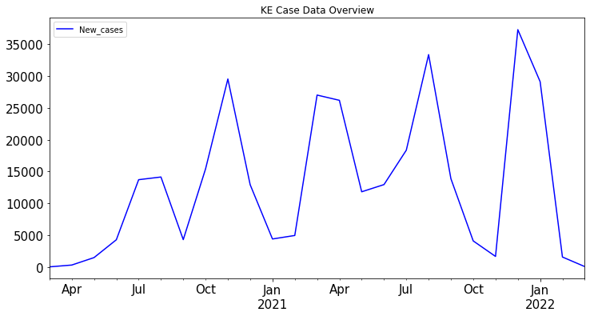

```python
interval = "M"
data_final.resample(interval).sum().plot(
    figsize=(12, 6),
    y=["New_cases"],
    color = "b",
    title = "KE Case Data Overview",
    fontsize = 15
);
```

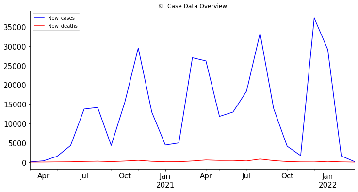

```python
data_final.resample(interval).sum().plot(
    figsize=(12, 6),
    y=["New_cases","New_deaths"],
    color = ["b","r"],
    title = "KE Case Data Overview",
    fontsize = 15
);
```

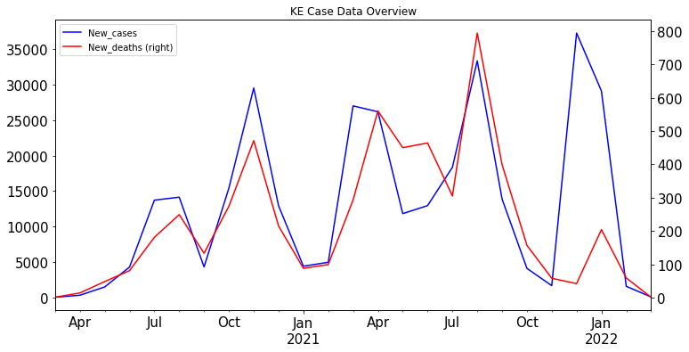

```python
data_final.resample(interval).sum().plot(
    figsize=(12, 6),
    y=["New_cases","New_deaths"],
    secondary_y=["New_deaths"],
    color = ["b","r"],
    title = "KE Case Data Overview",
    fontsize = 15
);
```

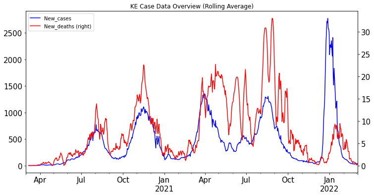

```python
data_final.rolling(7).mean().plot(
    figsize=(12, 6),
    y=["New_cases","New_deaths"],
    secondary_y=["New_deaths"],
    color = ["b","r"],
    title = "KE Case Data Overview (Rolling Average)",
    fontsize = 15
);
```

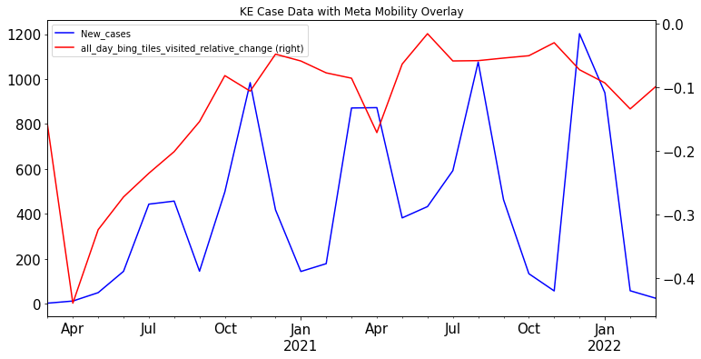

```python
#Comparing Mobility and New Cases
mobilityoverlayplt1 = data_final.resample(interval).mean().plot(
    figsize=(12, 6),
    y=["New_cases","all_day_bing_tiles_visited_relative_change"],
    secondary_y=["all_day_bing_tiles_visited_relative_change"],
    color = ["b","r"],
    title = "KE Case Data with Meta Mobility Overlay",
    fontsize = 15
);
```

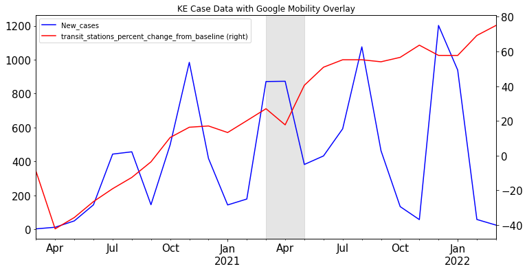

```python
#Comparing Mobility and New Cases
mobilityoverlayplt2 = data_final.resample(interval).mean().plot(
    figsize=(12, 6),
    y=["New_cases","transit_stations_percent_change_from_baseline"],
    secondary_y=["transit_stations_percent_change_from_baseline"],
    color = ["b","r"],
    title = "KE Case Data with Google Mobility Overlay",
    fontsize = 15
);
mobilityoverlayplt2.axvspan(xmin="2021-03-26", xmax="2021-05-01", color='grey', alpha=0.2)
```

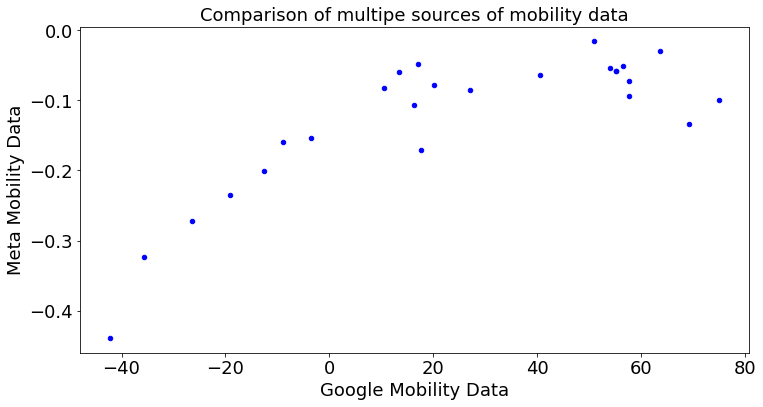

```python
#Using a scatter plot to compare different sources of mobility data
mobilityplt = data_final.resample(interval).mean().plot(
    x = "transit_stations_percent_change_from_baseline",
    y = "all_day_bing_tiles_visited_relative_change",
    kind="scatter",
    title = "Comparison of multipe sources of mobility data",
    color = "b",
    figsize=(12,6),
    fontsize = 18
);

mobilityplt.set_xlabel("Google Mobility Data", fontsize=18);
mobilityplt.set_ylabel("Meta Mobility Data", fontsize=18);
mobilityplt.set_title("Comparison of multipe sources of mobility data", fontsize=18);
```

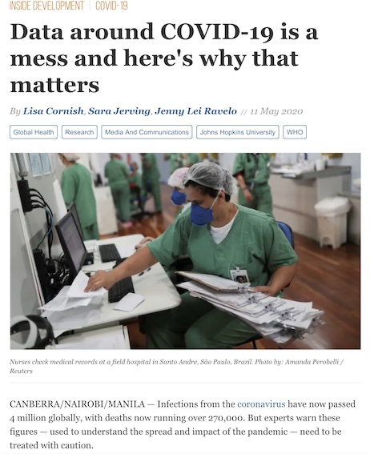

#### https://www.devex.com/news/data-around-covid-19-is-a-mess-and-here-s-why-that-matters-97077

I had the belief that reporting on weekends was bad.

Accordingly, I had the hypothesis that case data wouldn't be reliably reported till the following week

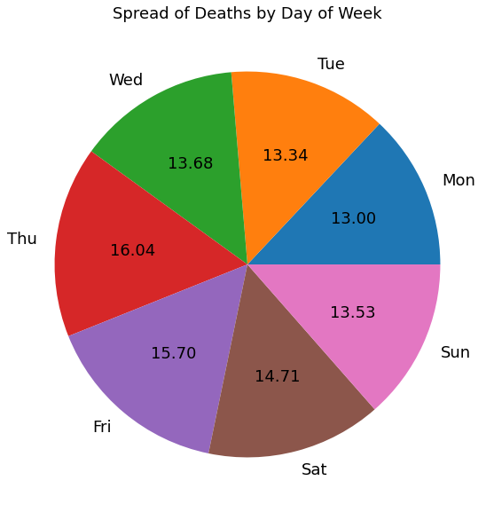

```python
pie = data_new.New_deaths.groupby(data_new.index.weekday).mean().plot(
    kind='pie',
    figsize=(10,10),
    autopct='%1.2f',
    labels =["Mon", "Tue", "Wed","Thu","Fri", "Sat","Sun"], #[cal.day_abbr[i] for i in range(7)]
    fontsize = 18, ylabel=""
);
pie.set_title("Spread of Deaths by Day of Week", fontsize=18);
```

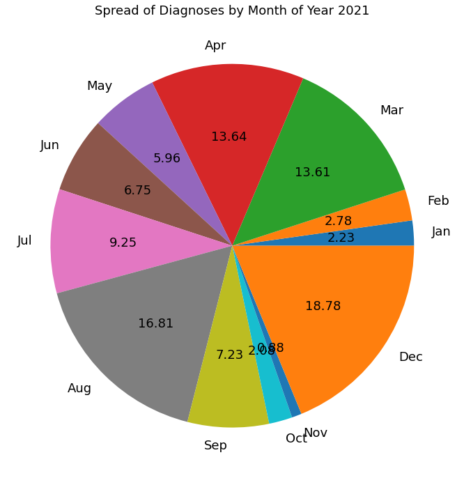

```python
pie = data_final[data_final.index.year==2021].resample("M").New_cases.mean().plot(
    kind='pie',
    figsize=(12,12),
    autopct='%1.2f',
    fontsize = 18,
    labels = [cal.month_abbr[i.month] for i in data_final[data_final.index.year==2021].resample("M").indices.keys()],
    ylabel=""
);
pie.set_title("Spread of Diagnoses by Month of Year 2021", fontsize=18);
```

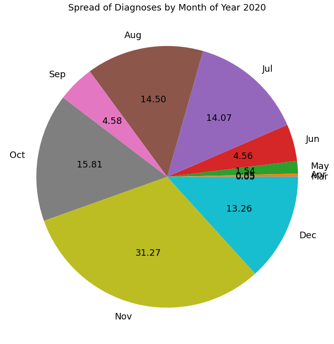

```python
import calendar as cal
pie = data_final[data_final.index.year==2020].resample("M").New_cases.mean().plot(
    kind='pie',
    figsize=(12,12),
    autopct='%1.2f',
    fontsize = 18,
    labels = [cal.month_abbr[i.month] for i in data_final[data_final.index.year==2020].resample("M").indices.keys()],
    ylabel=""
);
pie.set_title("Spread of Diagnoses by Month of Year 2020", fontsize=18);
```

```python
ke_cases = data[data.Country_code=="KE"].drop_duplicates().sort_values('Date_reported').set_index('Date_reported')
ng_cases = data[data.Country_code=="NG"].drop_duplicates().sort_values('Date_reported').set_index('Date_reported')
ug_cases = data[data.Country_code=="UG"].drop_duplicates().sort_values('Date_reported').set_index('Date_reported')
```

```python
from statsmodels.tsa.seasonal import STL #Season-Trend decomposition using LOESS
from statsmodels.tsa.api import SimpleExpSmoothing
```

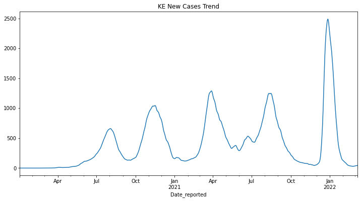

```python
stl_ke = STL(ke_cases.New_cases, period=12, seasonal=13)
res_ke = stl_ke.fit()
fig = res_ke.trend.plot()
fig.get_figure().set_size_inches(12, 6)
fig.set_title("KE New Cases Trend");
```

```python
exp_smooth_model = SimpleExpSmoothing(ke_cases.New_cases, initialization_method="estimated").fit()
exp_smooth_model.fittedvalues.plot(figsize=(12,6));
```

A Quick [Practical] Detour

```python
stl_ug = STL(ug_cases.New_cases, period=12, seasonal=13)
res_ug = stl_ug.fit()
fig = res_ug.trend.plot()
fig.get_figure().set_size_inches(12, 6)
fig.set_title("UG New Cases Trend");
```

```python
ug_cases.Cumulative_cases.plot(figsize=(12,6));
```

```python
ug_cases.New_cases.argmax()
#ug_cases.index[]
```

Saving figures!!

```python
fig.get_figure().savefig('somefigure.png')
pie.get_figure().savefig('piechart.png')
```

## Topics Covered

Data types/operations

The Pandas DataFrame

Loading data

Data slicing

Data filtering

Reindexing a DataFrame

Resampling time series data (daily to weekly, monthly)

Preview of plotting data

Using modules for time series analyses

"If there's a fourth wave in July-August (2021), it will most likely be due to delta," said Mr Patrick Amoth, the acting director-general for health at the ministry.

https://www.straitstimes.com/world/delta-covid-19-variant-may-spark-catastrophic-wave-in-kenya-in-weeks

Was there a "wave" in July-August in Kenya?

Is there anyway to infer if it such a wave was driven by Delta (or was driven by the existing variant)?